# Reproducible Research: Peer Graded Assignment 1

# Which 5-minute interval, on average across all the days in the dataset, contains the maximum number of steps?

```r
steps.interval$interval[which.max(steps.interval$steps)]
```

```
## [1] 835
```

# Calculate and report the total number of missing values in the dataset (i.e. the total number of rows with NAs)

```r
sum(is.na(activity))
```

```
## [1] 2304
```

# Devise a strategy for filling in all of the missing values in the dataset. The strategy does not need to be sophisticated. For example, you could use the mean/median for that day, or the mean for that 5-minute interval, etc.

# I will use means for 5 minute intervals.

# Create a new dataset that is equal to the original dataset but with the missing data filled in.

```r
activity <- merge(activity, steps.interval, by = "interval", suffixes = c("",
    ".y"))
nas <- is.na(activity$steps)
activity$steps[nas] <- activity$steps.y[nas]
activity <- activity[, c(1:3)]
```

# Make a histogram of the total number of steps taken each day and Calculate and report the mean and median total number of steps taken per day. Do these values differ from the estimates from the first part of the assignment? What is the impact of imputing missing data on the estimates of the total daily number of steps?

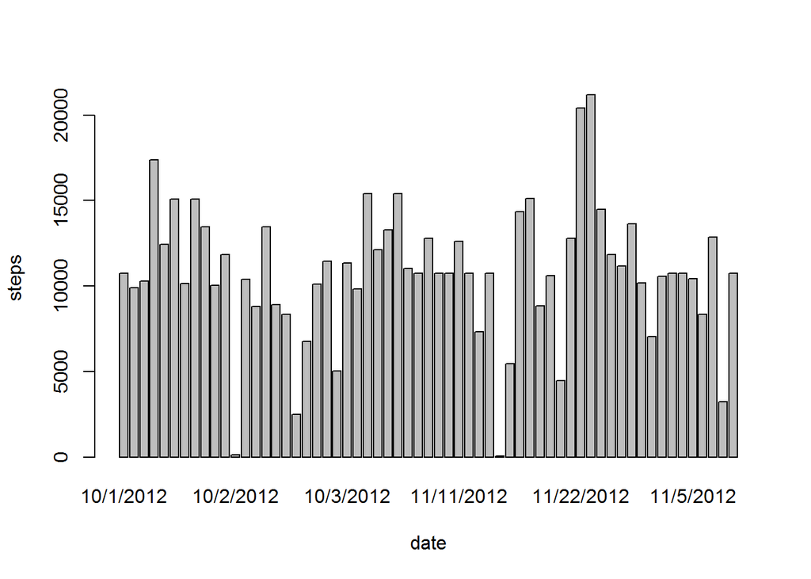

```r
steps.date <- aggregate(steps ~ date, data = activity, FUN = sum)
barplot(steps.date$steps, names.arg = steps.date$date, xlab = "date", ylab = "steps")
```

```r
mean(steps.date$steps)
```

```
## [1] 10766.19
```

```r
median(steps.date$steps)
```

```
## [1] 10766.19
```

# The missing data seems to have very little effect on the results, when estimating total number of steps per day.

# Are there differences in activity patterns between weekdays and weekends?

# For this part the weekdays() function may be of some help here. Use the dataset with the filled-in missing values for this part.

# 1. Create a new factor variable in the dataset with two levels – “weekday” and “weekend” indicating whether a given date is a weekday or weekend day.

# Convert activity$date to a date field

```r
activity$date <- as.Date(activity$date)
```

# Create a list of labels for each weekday

```r
wdayName <- c('Monday', 'Tuesday', 'Wednesday', 'Thursday', 'Friday')
```

# Use `%in%` and `weekdays` to create a logical vector. convert to `factor` and specify the `levels/labels`

# Use the weekdays function to determine the day of the week for each date

# and assign the appropriate weekend or weekday factor variable

```r
activity$dayType <-  factor((weekdays(activity$date) %in% wdayName) + 1L,
                            levels=1:2, labels=c('weekend', 'weekday'))
```

# Subset data into weekday and weekend dataframes

```r
actWday <- activity[activity$dayType == "weekday", ]
actWend <- activity[activity$dayType == "weekend", ]
```

# Calculate average Steps Per Interval for the weekday and weekend dataframes

```r
library(plyr)
avgStepsIntWday <- ddply(actWday,~interval,summarise,mean=mean(steps,na.rm = TRUE))
avgStepsIntWend <- ddply(actWend,~interval,summarise,mean=mean(steps,na.rm = TRUE))
```

# Add a dayType variable to each dataframe the combine the weekday and weekend dataframes

```r
avgStepsIntWday$dayType <- 'weekday'
avgStepsIntWend$dayType <- 'weekend'
avgStepsIntAll <- rbind(avgStepsIntWday, avgStepsIntWend)
```

# Two panel plots with Average Steps per Day - plotted by weekend and weekday

```r
library(lattice)
```

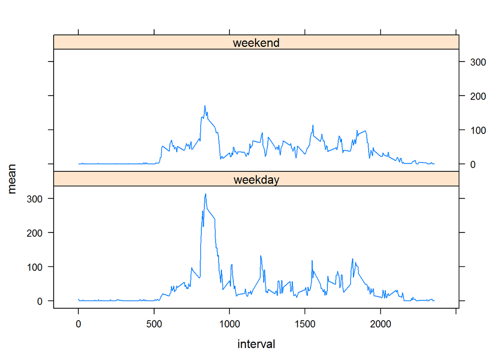

```r
xyplot(mean ~ interval | dayType, data = avgStepsIntAll, type ='l', layout = c(1, 2))
```